# Cox PH Regression: Selection Bias and Sample Size

Lecture 8D

PUBHBIO 6250

## Issues with the Hazard Ratio in Randomized Studies

- Consider a randomized trial where the primary interest is comparing survival across treatment groups.
- Randomization aims to construct treatment groups that are similar in characteristics related to the response, i.e., preventing confounders.

  *There should be no confounders in a randomized trial.*
- For the outcomes we learned earlier (e.g., binary, count), no regression modeling is needed to compare treatment groups as long as the randomization works.
  - An appropriate two-sample test is sufficient.
  - e.g., t-test, Wilcoxon rank-sum test
- However, with survival outcome, **regression modeling may be needed even in randomized studies** because the HR is subject to **selection bias**.

## Selection Bias Example

[Griffith et al. (2021)](https://www.nature.com/articles/s41467-020-19478-2) provide the following example:

- Suppose that academic and athletic (sporting) ability are two factors considered by a prestigious school when admitting a student.
- In the general population, these two factors are unrelated.
- But since this school tends to admit students with elite levels of at least one of the two factors, they are negatively correlated within its student population.

  *(indicated by the red dashed line)*

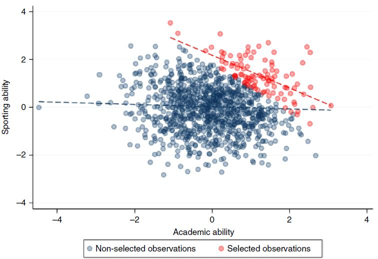

## Selection Bias of Hazard Ratio

- Recall the definition of the hazard function:

$$h(t)= \lim_{\Delta t \to 0} \frac{\Pr(t \le T < t + \Delta t \mid T \ge t)}{\Delta t}.$$

## Selection Bias of Hazard Ratio (Cont’d)

- The risk set at $t$ contains subjects with “better” values of $A$ and $X$ or both.
- As in the school admission example, conditioning on the risk set at $t$ **induces a correlation between $A$ and $X$**.
- This induced correlation makes $X$ a confounder at time $t+\Delta t$, leading to a biased effect of $A$ on $S_{t+\Delta t}$ if $X$ is not adjusted for, i.e., selection bias.

## Selection Bias of Hazard Ratio (Cont’d)

- If $A$ is not associated with survival risk, there is no selection bias.
- If $X$ is not associated with survival risk, there is no selection bias.
- Selection bias is always towards the null and doesn’t change the direction of effect of $A$.

## Selection Bias of HR in Randomized Studies

- If we are only interested in **testing the significance** of treatment effect, no need to account for selection bias.
  - A log rank test will be sufficient (since no confounders due to randomization).

    **Type-I error rate is maintained**, as there is no selection bias under the null.

    **Power is reduced** due to selection bias under the alternative.
- If we are also interested in **estimating the treatment effect**, we need to account for selection bias by **adjusting for predictors associated with survival outcome even if they are independent of $A$ (i.e., not confounders)**.
- Selection bias also exists in observational studies, making the model-building process more complicated than that for other outcome types.

## Sample Size Considerations in Cox Model

- In survival analysis, sample size considerations should focus on the **number of observed events** rather than the total number of subjects in a study.
  - Observed events contain the most information.
  - Censored observations contain limited information.
- Let $n$ be the total # of subjects, $n_*$ be the # of observed events, and $\pi$ be the censoring rate. Then $n_*=n(1-\pi)$.

## Sample Size Considerations in Cox Model (Cont’d)

- If a Cox model contains **only one binary predictor**, a formula is available to calculate the exact required number of events ($n_*$):

$$n_* = \frac{(z_{\beta} + z_{1-\alpha/2})^2}{\beta_0^2 \rho(1-\rho)},$$

- $\alpha$ is the two-sided type-I error rate
- $z_{1-\alpha/2}$ is the $100\times (1-\alpha/2)$-th percentile of a standard normal distribution
- $\beta$ is the desired statistical power
- $z_{\beta}$ is the $100\times \beta$-th percentile of a standard normal distribution
- $\beta_0$ is the target log hazard ratio to be detected
- $\rho$ is the proportion of a given level of the binary predictor
- The sample size $n$ is calculated as $n = n_{*}/(1-\pi)$, $\pi$ is the anticipated censoring rate.

## Example: Sample Size Considerations

- A randomized clinical trial is designed to evaluate the effect of a novel chemotherapy on the overall survival of lung cancer patients.
- Patients will be randomized to the novel or standard therapy at a 1:1 ratio.
- Aim to detect a **hazard ratio of 0.5** (novel vs. standard therapy) using the Cox model with treatment group as the single predictor.
- Aim to achieve **90% power** while maintaining a **5% two-sided type-I error rate**.
- Anticipated censoring rate is **25%**.
- **Question**: What is the required sample size under this design?
  - 90% power $\to z_{\beta}=z_{0.9}=1.28$.
  - 5% two-sided type-I error rate $\to z_{1-\alpha/2}=z_{0.975}=1.96$.
  - $\beta_0 = \text{log(desired HR)}=\text{log}(0.5)=-0.693$.
  - $\rho=0.5$ (proportion of novel therapy in the sample due to 1:1 randomization)
  - Censoring rate $\pi=0.25$.

## Example: Sample Size Considerations (Cont’d)

- Let’s first calculate the required number of events (death).

$$n_*=\frac{(1.28 + 1.96)^2}{(-0.693)^2 \times 0.5 \times (1-0.5)}\approx 88 \quad \text{(round up)}$$

- The required total number of patients is:

$$n=\frac{n_*}{1-\pi}=\frac{88}{1-0.25} \approx 118 \quad \text{(round up to the nearest even number)}$$

- **NOTE**: Always round up!

## Sample Size Considerations in Cox Model (Cont’d)

- **No formula** exists for calculating the required number of events for Cox models with multiple predictors (categorical and continuous).

  *Since it depends on many factors (e.g., correlations among the predictors).*
- Use **rules of thumb** to guide the sample size determination.

  *Based on simulations under limited settings, they are **guidelines**, not hard rules.*
- **Commonly used rules of thumb**
  - For categorical predictors, at least **five** events in each category.
  - For interaction between two categorical predictors, at least **five** events in each combination of categories of the two predictors.
  - At least **five** events for each predictor (dummy variables and interaction terms).

    *Example*: If there are 27 observed events in a dataset, we can include **at most** $27/5 \approx 5$ predictors in a Cox regression model (**round down**).